# Diversity and team-performance meta-analysis

# Publication bias analyses

```r
datasets_pub <- dataset %>%
  filter(pub_status == "Published") %>%
  split(.$domain)

# Exploratory analysis - are *claims* about diversity shaped by publication bias?
datasets_pub_focal <- dataset %>%
  filter(pub_status == "Published", art_focus == "focal H") %>%
  split(.$domain)
```

## Funnel plots

We used an Egger’s regression test to assess the asymmetry of the funnel plot, with Robust Variance Estimation (RVE) taking care of dependence between effect sizes. In order to strike an appropriate balance between statistical power and Type I errors, we followed the common practice highlighted by Siegel and colleagues (2021) and interpreted p-values below .1 as evidence for publication bias.

Given that publication bias tests are assessments of what is reported in the literature, they are based on *unadjusted* correlation coefficients and standard errors. As the dataset included a few estimates based on small samples, with very large standard errors, we trimmed the funnel plots at the 1% percentile of the standard error distribution to improve legibility. The Egger’s regression tests were conducted on the full sample.

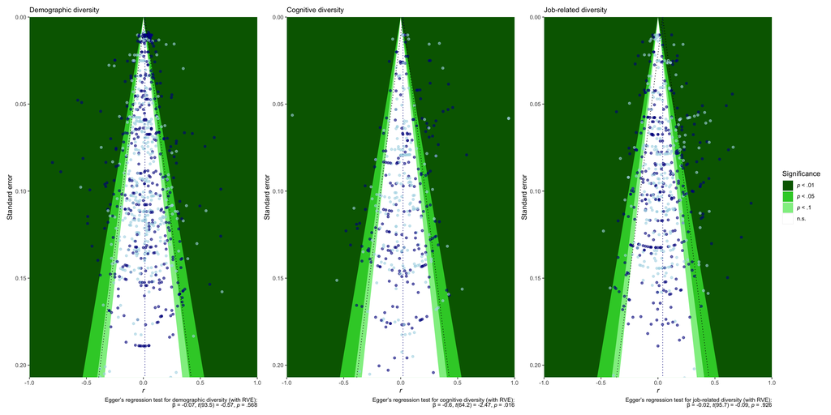

```r
funnel_plots <- list()

trim_pct <- 1

max_se <- dataset %>%
    filter(pub_status == "Published", art_focus == "focal H") %>%
  pull(se) %>% quantile(1-trim_pct/100)

for (domain in names(datasets_pub)) {

cur_data <- datasets_pub[[domain]]

# Load earlier estimate?
confidence_intervals <- read_rds("data/main_meta_res.rds")

estimate <- confidence_intervals$beta[confidence_intervals$Coef == paste0("domain", domain)]
se <- confidence_intervals$SE[confidence_intervals$Coef == paste0("domain", domain)]

# Now, compute vectors of the lower-limit and upper limit values for the 95% CI around the metanalytic estimate
se.seq = seq(0,  max_se, 0.001)
ll95 = estimate - (1.96*se.seq)
ul95 = estimate + (1.96*se.seq)

# And the various around 0
ll95_0 = 0 - (1.96*se.seq)
ul95_0 = 0 + (1.96*se.seq)
ll90_0 = 0 - (1.65*se.seq)
ul90_0 = 0 + (1.65*se.seq)
ll99_0 = 0 - (2.58*se.seq)
ul99_0 = 0 + (2.58*se.seq)

# Now, smash all of those calculated values into one data frame (called 'dfCI').
dfCI <- data.frame(ll95, ul95, ll95_0, ul95_0, ll99_0, ul99_0, ll90_0, ul90_0, se.seq, estimate)

# Add a color column to the dataset based on the specified criteria
cur_data$color <- ifelse(cur_data$art_focus == "focal H",
                        "darkblue",
                        "lightblue")


   V <- with(cur_data,
            impute_covariance_matrix(vi = se^2,
                                    cluster = articlestudy,
                                    r = rho))

    egger_multi <- rma.mv(yi = r_rep, V = V, random = ~ 1 | articlestudy / effect_id, mods = ~ se, data = cur_data)


    coefs <-  coef_test(egger_multi, vcov = "CR2")

    eggers_label <- glue::glue("Egger's regression test for {domain %>% tolower()} diversity (with RVE):<br> β = {round(coefs$beta[2], 2)}, *t*({round(coefs$df_Satt[2], 1)}) = {round(coefs$t[2], 2)}, *p* {fmt_p(coefs$p[2])}")

fill_colors <- c("n.s." = "white", "*p* < .1" = "#90EE90", "*p* < .05" = "#32CD32", "*p* < .01" = "#006400")

# Make the funnel plot.
funnel_plots[domain] <- list(ggplot(data = cur_data) +
  xlab('r') + ylab('Standard Error') +
    annotate("rect", xmin = -1, xmax = 1, ymin = 0, ymax = max(dfCI$se.seq), fill = "#006400") +
  geom_ribbon(data = dfCI, aes(xmin = ll99_0, xmax = ul99_0, y = se.seq, fill = "*p* < .05")) +
  geom_ribbon(data = dfCI, aes(xmin = ll95_0, xmax = ul95_0, y = se.seq, fill = "*p* < .1" )) +
geom_ribbon(data = dfCI, aes(xmin = ll90_0, xmax = ul90_0, y = se.seq, fill = "n.s.")) +
  # Dummy layer for the annotated color
  geom_ribbon(aes(y = 0, xmin = Inf, xmax = Inf, fill = "*p* < .01")) +

    scale_fill_manual("Significance", values = fill_colors) +
    geom_point(aes(y = se, x = r_rep, color = color), alpha = .6) +
  scale_color_identity() +
  geom_line(aes(y = se.seq, x = ll95), linetype = 'dotted', linewidth = .5, data = dfCI) +
  geom_line(aes(y = se.seq, x = ul95), linetype = 'dotted', linewidth = .5, data = dfCI) +
  geom_line(aes(x = estimate, y = se_range),
            data = tibble(estimate = estimate, se_range = c(0, max(dfCI$se.seq))),
            linetype = 'dotted', color = 'darkblue', linewidth = .5) +
  scale_x_continuous() +
  coord_cartesian(xlim = c(-1, 1), ylim = c(max(dfCI$se.seq), 0), expand = FALSE) +
  #scale_y_continuous(trans = "reverse", limits = c(0, -max(dfCI$se.seq))) +
  labs(subtitle = paste0(domain %>% str_remove("domain"), " diversity"),
       caption = eggers_label, x = "*r*", y = "Standard error") +
    theme(plot.caption = ggtext::element_markdown(),
          axis.title.x = ggtext::element_markdown(),
          legend.text = ggtext::element_markdown(),
          panel.grid = element_blank()))
}


funnels <- wrap_plots(funnel_plots, ncol = 3, tag_level = "new", guides = "collect")

ggsave("figures/funnel_plots.png", funnels, width = 30, height = 15, dpi = 300, units = "cm")

funnels
```

There is no evidence that effect size is associated with standard errors for demographic and job-related diversity - so that *positive* results appear to be no more likely to be published than others. Note that this does not enable us to test for publication bias in favour of significant results in *either* direction.

Surprisingly, positive results in small studies on cognitive diversity appear *less* likely to get published for cognitive diversity. However, it appears more plausible that these are small study effects other than publication bias against significant studies.

## 3 PSM

Selection models (of either type) cannot presently be extended to account for dependent effect sizes but sampling one effect size per sample results in a test that combines comparatively high power with a predictable Type I error rate. Therefore, we bootstrapped 3PSM with effect size sampling, and report the median results and distribution of 5,000 bootstrap resamples. Roders & Pustejovsky show that sampling leads to much lower Type I error rates than ignoring dependency or aggregating effects for 3PSM. Given that an alpha level of .05 is associated with a Type I error rate of up to 10%, we relied on this threshold (Rodgers & Pustejovsky, 2021).

Most recent (preliminary) results by Pustejovsky (2023 - https://www.jepusto.com/cluster-bootstrap-selection-model/) suggest that the cluster bootstraps (i.e. sampling at the study rather than the effect size level) may be the most accurate method for estimating selection models in the presence of dependent effects, so that we present this approach as supplementary.

Bootstrapping these models takes a considerable amount of time, so was done on an AWS virtual machine. The full code is provided in `helpers/aws_code 3PSM.R`, and below as an illustration.

```r
# Define a function for the selection model
apply_selmodel <- function(data, boot_method = c("within", "cluster")) {
  if (boot_method == "within") {
     data <- data %>% group_by(articlestudy) %>% sample_n(1) %>% ungroup() %>%   # Sample one effect size per study
       sample_n(nrow(.), replace = TRUE) # Create bootstrap sample
  } else if (boot_method == "cluster") {
    data <- data %>% nest(.by = articlestudy, .key = "data") %>% sample_n(nrow(.), replace = TRUE) %>% unnest(data)
  } else {
    stop("Invalid boot_method")
  }

    run_selmodel <- function (data) {
    # Fit the model
    m.rma <- rma(yi = r_rep,
                sei = se,
                data = data,
                slab = articlestudy,
                method = "REML",
                test = "knha")

    selmodel(m.rma,
            type = "stepfun",
            skiphes = TRUE, skiphet = TRUE, # turn off SE and het-test calculations to accelerate,
            steps = c(0.025, .05, .95, .975)) %>%  # Selection for both positive and negative sig values
        summary()

    }

    run_selmodel <- purrr::possibly(run_selmodel, otherwise = NA)

    psm_mod <- run_selmodel(data)

    browser()

    if (is.na(psm_mod[1])) {
      return(tibble())
    } else {

    # Create dataframe with the required elements
    tibble(
        lrt = psm_mod$LRT,
        p_table = list(psm_mod$ptable %>% mutate(prob = psm_mod$delta))
    )
    }
}

# Bootstrap sampling and applying 3PSM
set.seed(123)
n_bootstraps <- 5000
plan(multisession, workers = 6)

if (!file.exists("data/sel_models_within.qs")) {
  with_progress({
   p <- progressor(steps = n_bootstraps * 3, label = "Bootstrapping")
sel_models_within <- map_dfr(datasets_pub, \(domain_data) {
  future_map_dfr(seq_len(n_bootstraps) %>% set_names(), \(i) {
    p()
    apply_selmodel(domain_data, boot_method = "within")
  }, .id = "run", .options = furrr_options(seed = TRUE))}, .id = "domain")
 })
} else {
  sel_models_within <- qs::qread("data/sel_models_within.qs")
}

if (!file.exists("data/sel_models_cluster.qs")) {

with_progress({
   p <- progressor(steps = n_bootstraps * 3, label = "Bootstrapping")
   sel_models_cluster <- map_dfr(datasets_pub, \(domain_data) {
   future_map_dfr(seq_len(n_bootstraps) %>% set_names(), \(i) {
     p()
     apply_selmodel(domain_data, boot_method = "cluster")
   }, .id = "run", .options = furrr_options(seed = TRUE))}, .id = "domain")
 })
} else {
  sel_models_cluster <- qs::qread("data/sel_models_cluster.qs")
}
```

[figure not shown]

```r
# Calculate median estimates
within_ps <- map2_dfr(sel_models_within$domain, sel_models_within$p_table, \(d, ptab)
                      ptab %>% rownames_to_column() %>% mutate(domain = d))
median_estimate_within <- within_ps %>% group_by(rowname, domain) %>% summarise(p = median(prob), .groups = "drop")

cluster_ps <- map2_dfr(sel_models_cluster$domain, sel_models_cluster$p_table, \(d, ptab)
                      ptab %>% rownames_to_column() %>% mutate(domain = d))
median_estimate_cluster <- cluster_ps  %>% group_by(rowname, domain) %>% summarise(p = median(prob), .groups = "drop")

ps_summary <- within_ps %>% mutate(method = "within") %>%
  bind_rows(cluster_ps %>% mutate(method = "cluster")) %>%
  mutate(group = rowname) %>%
  separate_rows(rowname, sep = "<=|<|>") %>%
    filter(rowname != " p ") %>%
    mutate(p = as.numeric(rowname)) %>%
  group_by(domain, method, group, p) %>%
  summarise(median = median(prob),
         ci_low95 = quantile(prob, .025),
         ci_high95 = quantile(prob, .975),
         ci_low90 = quantile(prob, .05),
         ci_high90 = quantile(prob, .95), .groups = "drop") %>%
  mutate(p = 1-p) %>%
  arrange(desc(row_number())) %>%
  mutate(sig = ifelse(sign(ci_low95-1) == sign(ci_high95-1), "*",
                      ifelse(sign(ci_low90-1) == sign(ci_high90-1), "†", "")))

sig_segments <- ps_summary %>%
  filter(sig != "", ci_low95 != ci_high95) %>% # Remove reference category
  group_by(domain, method, group, median, ci_low95, ci_high95, sig) %>%
  summarise(p = min(p) + .0125, .groups = "drop") %>%
  mutate(p = case_when(
           round(p, 4) == 0.0625 ~ .1,
           .default = p
         ))

es_plt <- ps_summary %>%
  filter(method == "cluster") %>%
  ggplot(aes(x = p, y = median, color = domain)) +
  geom_line() +
  geom_ribbon(aes(ymin = ci_low95, ymax = ci_high95, fill = domain), alpha = .2, linewidth = 0) +
  facet_wrap(~domain, ncol = 1,                 strip.position="right") +
  scale_y_log10(breaks = c(.25, .5, 1, 2, 4), labels = c(.25, .5, 1, 2, 4)) +
  scale_x_continuous(breaks = c(.025, .05, .1, .95, .975), labels = c("< .05 (neg)", "< .1", "n.s.", "< .1", "< .05 (pos)")) +
  scale_x_break(c(.11, .93), space = 0, expand = FALSE) +
  labs(subtitle = "Effect size bootstrapping", y = "Relative publication odds", x = "Significance level and direction") +
  theme_minimal() +
  theme(legend.position = "none",
        axis.title.x = ggtext::element_markdown()) +
  geom_hline(yintercept = 1, linetype = "dashed", color = "grey40") +
  geom_text(data = sig_segments %>% filter(method == "cluster"), aes(x = p, y = median, label = sig), color = "black", size = 5, nudge_y = .1)

cluster_plt <- ps_summary %>%
  filter(method == "within") %>%
  ggplot(aes(x = p, y = median, color = domain)) +
  geom_line() +
  geom_ribbon(aes(ymin = ci_low95, ymax = ci_high95, fill = domain), alpha = .2, linewidth = 0) +
  facet_wrap(~domain, ncol = 1,                 strip.position="right") +
  scale_y_log10(breaks = c(.25, .5, 1, 2, 4), labels = c(.25, .5, 1, 2, 4)) +
  scale_x_continuous(breaks = c(.025, .05, .1, .95, .975), labels = c("< .05 (neg)", "< .1", "n.s.", "< .1", "< .05 (pos)")) +
  scale_x_break(c(.11, .93), space = 0, expand = FALSE) +
  labs(subtitle = "Cluster bootstrapping", y = "", x = "Significance level and direction") +
    theme_minimal() +
  theme(legend.position = "none",
        axis.title.x = ggtext::element_markdown()) +
  geom_hline(yintercept = 1, linetype = "dashed", color = "grey40")+
  geom_text(data = sig_segments %>% filter(method == "within"), aes(x = p, y = median, label = sig), color = "black", size = 5, nudge_y = .1)

selection_model <- es_plt + cluster_plt

ggsave("figures/selection_model.png", selection_model)

selection_model
```

```r
ps_summary %>%
  mutate(`Significance level` = case_when(
group == "0     < p <= 0.025" ~ "*p* < .05 (pos)",
group == "0.025 < p <= 0.05" ~ "*p* < .1 (pos)",
group == "0.05  < p <= 0.95" ~ "n.s.",
group == "0.95  < p <= 0.975" ~ "*p* < .1 (neg)",
group == "0.975 < p <= 1" ~ "*p* < .05 (neg)",
TRUE ~ NA_character_
),
`Publication Odds` = case_when(`Significance level` == "*p* < .05 (pos)" ~ "1 (reference)",
                               TRUE ~ glue::glue("{round_(median)} {fmt_ci(ci_low95, ci_high95)} {sig}"))) %>%
  select(Domain = domain, method, `Significance level`, `Publication Odds`) %>%
  distinct() %>%
  pivot_wider(names_from = method, values_from = c(`Publication Odds`), names_glue = "Publication Odds ({method})") %>%
  group_by(Domain) %>%
  gt() %>%
  fmt_markdown(columns = c(`Significance level`)) %>%
  gt_apa_style()
```

| Significance level | Publication Odds (within) | Publication Odds (cluster) |
| --- | --- | --- |
| Job-related |  |  |
| *p* < .05 (neg) | 1.79 [0.60, 4.94] | 1.63 [0.79, 3.33] |
| *p* < .1 (neg) | 2.82 [0.80, 7.64] † | 2.88 [1.45, 5.61] * |
| n.s. | 2.05 [1.10, 3.90] * | 2.23 [1.44, 3.51] * |
| *p* < .1 (pos) | 1.56 [0.62, 3.14] | 1.23 [0.69, 2.04] |
| *p* < .05 (pos) | 1 (reference) | 1 (reference) |
| Demographic |  |  |
| *p* < .05 (neg) | 0.38 [0.14, 1.00] * | 0.32 [0.13, 0.73] * |
| *p* < .1 (neg) | 0.86 [0.27, 2.33] | 0.72 [0.31, 1.64] |
| n.s. | 1.25 [0.61, 2.52] | 1.05 [0.54, 1.99] |
| *p* < .1 (pos) | 0.90 [0.28, 2.07] | 1.00 [0.59, 1.61] |
| *p* < .05 (pos) | 1 (reference) | 1 (reference) |
| Cognitive |  |  |
| *p* < .05 (neg) | 0.77 [0.19, 2.79] | 0.81 [0.36, 2.02] |
| *p* < .1 (neg) | 1.35 [0.30, 4.84] | 1.97 [0.83, 4.37] |
| n.s. | 1.67 [0.73, 4.07] | 2.24 [1.06, 4.52] * |
| *p* < .1 (pos) | 1.06 [0.27, 2.91] | 1.39 [0.58, 3.05] |
| *p* < .05 (pos) | 1 (reference) | 1 (reference) |